```python
from setup import *
```

# Simulate FFPE samples using PCAWG mutation profiles

## Read FFPE signatures

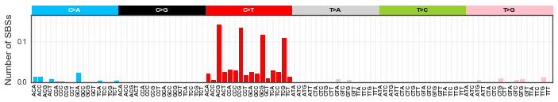

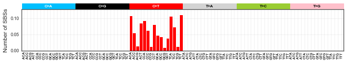

```python
SBS96_plot(ffpe_sig_repaired)
SBS96_plot(ffpe_sig_unrepaired)
```

## Read PCAWG mutational profiles

```python
profiles = pd.read_csv("./Data/WGS_PCAWG.96.csv")
profile_values = profiles.iloc[:,2:]
profiles.head(2)
```

|  | Mutation type | Trinucleotide | Biliary-AdenoCA::SP117655 | Biliary-AdenoCA::SP117556 | Biliary-AdenoCA::SP117627 | Biliary-AdenoCA::SP117775 | Biliary-AdenoCA::SP117332 | Biliary-AdenoCA::SP117712 | Biliary-AdenoCA::SP117017 | Biliary-AdenoCA::SP117031 | ... | Uterus-AdenoCA::SP94540 | Uterus-AdenoCA::SP95222 | Uterus-AdenoCA::SP89389 | Uterus-AdenoCA::SP90503 | Uterus-AdenoCA::SP92460 | Uterus-AdenoCA::SP92931 | Uterus-AdenoCA::SP91265 | Uterus-AdenoCA::SP89909 | Uterus-AdenoCA::SP90629 | Uterus-AdenoCA::SP95550 |
| --- | --- | --- | --- | --- | --- | --- | --- | --- | --- | --- | --- | --- | --- | --- | --- | --- | --- | --- | --- | --- | --- |
| 0 | C>A | ACA | 269 | 114 | 105 | 217 | 52 | 192 | 54 | 196 | ... | 117 | 233 | 94 | 114 | 257 | 139 | 404 | 97 | 250 | 170 |
| 1 | C>A | ACC | 148 | 56 | 71 | 123 | 36 | 139 | 54 | 102 | ... | 90 | 167 | 59 | 64 | 268 | 75 | 255 | 78 | 188 | 137 |

2 rows × 2782 columns

## Simulate PCAWG FFPE samples

```python
def simulation(sample_indvidual, ffpe_sig, ffpe_load):
    v = sample_indvidual + poisson.rvs(ffpe_sig * ffpe_load)
    return (v)

simulated_df_unrepaired_10_4, simulated_df_repaired_10_4 = pd.DataFrame(), pd.DataFrame()
for i, col in enumerate(profile_values.columns):
    npr.seed(i + 1)
    sample = profiles[col].to_numpy()
    simulated_df_unrepaired_10_4 [col] = simulation(sample_indvidual = sample,
                                                    ffpe_sig = ffpe_sig_unrepaired,
                                                    ffpe_load = 10**4)

    simulated_df_repaired_10_4 [col] = simulation(sample_indvidual = sample,
                                                    ffpe_sig = ffpe_sig_repaired,
                                                    ffpe_load = 10**4)
## write the simulated samples to Data folder
simulated_df_unrepaired_10_4.to_csv ("./Data/simulated_PCAWG_FFPE_unrepaired.csv", index = False)
simulated_df_repaired_10_4.to_csv ("./Data/simulated_PCAWG_FFPE_repaired.csv", index = False)
```

# Correction of FFPE noise in the simulated samples

## One example of correcting FFPE profile

We performed the same cleaning process for all simulated samples on the HPC (Apoctria, Queen Mary University of Longon) due to the long running time on local PC. Here we show an example on how it work.

```python
example_sample = "ColoRect-AdenoCA::SP17329"
cancer_type, sample_id =  example_sample.split("::")
biological_profile = profile_values[example_sample].to_numpy()
ffpe_profile = simulated_df_unrepaired_10_4[example_sample]

corrected_profile, corrected_profiles_df = correct_FFPE_profile(v = ffpe_profile.to_numpy(),
                                                                w1 = ffpe_sig_unrepaired,
                                                                sample_id= sample_id)
```

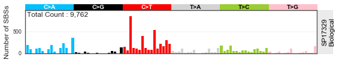

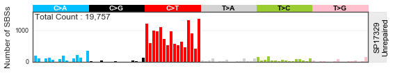

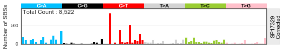

```python
## plot all profiles
SBS96_plot(biological_profile, label = f"{sample_id}\nBiological", xticks = False,
           height = 1.6, width = 8, s = 10)

SBS96_plot(ffpe_profile, label = f"{sample_id}\nUnrepaired",
           height = 1.6, width = 8, xticks = False, s = 10)

SBS96_plot(corrected_profile, label = f"{sample_id}\nCorrected", xticks = False,
          height = 1.6, width = 8, s = 10)
```

```python
n_channel = len(biological_profile)
cs = np.round(cosine_similarity(biological_profile.reshape(1,n_channel),
                           corrected_profile.reshape(1,n_channel))[0][0], 3)

reverse_T2C_ind = ["T>C" not in t for t in profiles['Mutation type']]
cs_80c = np.round(cosine_similarity(biological_profile[reverse_T2C_ind].reshape(1,80),
                           corrected_profile[reverse_T2C_ind].reshape(1,80))[0][0], 3)
print ("Compare corrected profile to biological profile(96c):", cs)
print ("Compare corrected profile to biological profile(80c):", cs_80c)
```

```
Compare corrected profile to biological profile(96c): 0.977
Compare corrected profile to biological profile(80c): 0.975
```

## Read data from cleaning results for all simulated unrepaired/repaired FFPE

**NOTE:** The correction process is the same for all PCAWG samples as shown in the above example. To save time, we did parallel-run in our local HPC cluster. Here, we will read the collected results for all samples from the cluster.

Also, we will compute the correction accuracy on nonT2C channels(80-channel). As there is no noise introduced in T>C channels, thus the mutation counts for those channel will remain. And the remained counts in those channels will increase the accuracy, but it was due to our correction method. So we focus on accuracy from the remaining 80-channels.

```python
## unrepaired FFPE:
unrepaired_profiles_corrected = pd.read_csv("./Data/unrepaired_profiles_corrected.csv", sep ="\t")

## collecting accuracy
reverse_T2C_ind = ["T>C" not in t for t in profiles['Mutation type']]
accuracy_unrepaired = [cosine_similarity(profile_values[col][reverse_T2C_ind].to_numpy().reshape(1,80),
                        unrepaired_profiles_corrected[col][reverse_T2C_ind].to_numpy().reshape(1,80))[0][0]
                       for col in unrepaired_profiles_corrected.columns[1:]]

## computing similarities between FFPE sig (the noise) and the original profile(the signal)
similarity_unrepaired = [cosine_similarity(profile_values[col][reverse_T2C_ind].to_numpy().reshape(1,80),
                            ffpe_sig_unrepaired[reverse_T2C_ind].reshape(1,80))[0][0]
                         for col in unrepaired_profiles_corrected.columns[1:]]

## Build dataframe
unrepaired_stat = pd.DataFrame()
unrepaired_stat['Samples'] = profiles.columns[2:]
unrepaired_stat['Cancer_type'] = [col.split("::")[0] for col in profiles.columns[2:]]

unrepaired_stat['Correction_accuracy'] = accuracy_unrepaired
unrepaired_stat['Similarity_FFPEsig_original'] = similarity_unrepaired

## label the mutation load group: top 10% as high, bottom 10% as low, others are middle
load_values = profiles.iloc[:,2:].loc[reverse_T2C_ind,:].sum()
load_lower, load_upper = np.quantile(load_values, [0.1,0.9])

unrepaired_stat['mutationload_label'] = "Middle"
unrepaired_stat['mutationload_label'].values[load_values < load_lower] = "Low"
unrepaired_stat['mutationload_label'].values[load_values > load_upper] = "High"

## label the similarity group: top 10% as high, bottom 10% as low, others are middle
sim_values_unrepaired = unrepaired_stat.Similarity_FFPEsig_original.values
sim_lower, sim_upper = np.quantile(sim_values_unrepaired, [0.1,0.9])
unrepaired_stat['similarity_label'] = "Middle"
unrepaired_stat['similarity_label'].values[sim_values_unrepaired < sim_lower] = "Low"
unrepaired_stat['similarity_label'].values[sim_values_unrepaired > sim_upper] = "High"

unrepaired_stat.head(2)
```

|  | Samples | Cancer_type | Correction_accuracy | Similarity_FFPEsig_original | mutationload_label | similarity_label |
| --- | --- | --- | --- | --- | --- | --- |
| 0 | Biliary-AdenoCA::SP117655 | Biliary-AdenoCA | 0.966495 | 0.646440 | Middle | Middle |
| 1 | Biliary-AdenoCA::SP117556 | Biliary-AdenoCA | 0.956505 | 0.488403 | Middle | Middle |

```python
## Repaired FFPEs:
repaired_profiles_corrected = pd.read_csv("./Data/repaired_profiles_corrected.csv", sep ="\t")

## collecting accuracy
accuracy_repaired = [cosine_similarity(profile_values[col][reverse_T2C_ind].to_numpy().reshape(1,80),
                              repaired_profiles_corrected[col][reverse_T2C_ind].to_numpy().reshape(1,80))[0][0]
            for col in repaired_profiles_corrected.columns[1:]]

## computing similarities between FFPE sig (the noise) and the original profile(the signal)
similarity_repaired = [cosine_similarity(profile_values[col][reverse_T2C_ind].to_numpy().reshape(1,80),
                              ffpe_sig_repaired[reverse_T2C_ind].reshape(1,80))[0][0]
            for col in repaired_profiles_corrected.columns[1:]]

## Build dataframe
repaired_stat = pd.DataFrame()
repaired_stat['Samples'] = profiles.columns[2:]
repaired_stat['Cancer_type'] = [col.split("::")[0] for col in profiles.columns[2:]]

repaired_stat['Correction_accuracy'] = accuracy_repaired
repaired_stat['Similarity_FFPEsig_original'] = similarity_repaired

## label the mutation load group: top 10% as high, bottom 10% as low, others are middle
repaired_stat['mutationload_label'] = "Middle"
repaired_stat['mutationload_label'].values[load_values < load_lower] = "Low"
repaired_stat['mutationload_label'].values[load_values > load_upper] = "High"

## label the similarity group: top 10% as high, bottom 10% as low, others are middle
sim_values_repaired = repaired_stat.Similarity_FFPEsig_original.values
sim_lower, sim_upper = np.quantile(sim_values_repaired, [0.1,0.9])
repaired_stat['similarity_label'] = "Middle"
repaired_stat['similarity_label'].values[sim_values_repaired < sim_lower] = "Low"
repaired_stat['similarity_label'].values[sim_values_repaired > sim_upper] = "High"

repaired_stat.head(2)
```

|  | Samples | Cancer_type | Correction_accuracy | Similarity_FFPEsig_original | mutationload_label | similarity_label |
| --- | --- | --- | --- | --- | --- | --- |
| 0 | Biliary-AdenoCA::SP117655 | Biliary-AdenoCA | 0.957317 | 0.570321 | Middle | Middle |
| 1 | Biliary-AdenoCA::SP117556 | Biliary-AdenoCA | 0.888327 | 0.837826 | Middle | Middle |

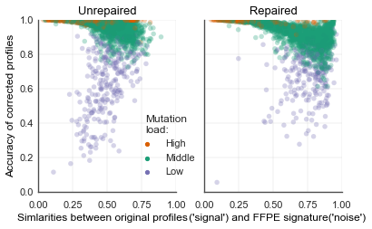

```python
## overall correction accuracy

f, (ax1, ax2) = plt.subplots(1,2, figsize=(6, 3.5), sharey = True, sharex =True)
sns.scatterplot(x = "Similarity_FFPEsig_original", y = "Correction_accuracy",
                hue = "mutationload_label", palette = "Dark2", edgecolor='',
                data = unrepaired_stat,  alpha = 0.3, s = 30, ax = ax1)
ax1.set_xlim(0,1)
ax1.set_ylim(0,1)

ax1.set_xlabel("Simlarities between original profiles   ",
           size = 12, color = "black")
ax1.set_ylabel("Accuracy of corrected profiles", size = 12, color = "black")

handles, labels = ax1.get_legend_handles_labels()

ax1.legend([handles[2], handles[1], handles[3]],
           [labels[2], labels[1], labels[3]],
           bbox_to_anchor=(0.65, 0.5),
           frameon = False, title = "Mutation\nload:", markerscale = 0.7, ncol = 1)
ax1.set_title ("Unrepaired", color = "black", size = 13)
sns.scatterplot(x = "Similarity_FFPEsig_original", y = "Correction_accuracy",
                hue = "mutationload_label", palette = "Dark2", edgecolor='',
                data = repaired_stat,  alpha = 0.3, s = 30, ax = ax2, legend = None )
ax2.set_xlim(0,1)
ax2.set_ylim(0,1)
sns.despine()
ax2.set_xlabel ("   ('signal') and FFPE signature('noise')",size = 12, color = "black")
ax2.set_title ("Repaired", color = "black", size = 13)

plt.show()
```

```python
unrepaired_mean_CI = np.around(mean_confidence_interval(unrepaired_stat['Correction_accuracy']),3)
print (f'Mean and 95% CI for Unrepaired FFPE correction: {unrepaired_mean_CI}')

repaired_mean_CI = np.around(mean_confidence_interval(repaired_stat['Correction_accuracy']),3)
print (f'Mean and 95% CI for Repaired FFPE correction: {repaired_mean_CI}')
```

```
Mean and 95% CI for Unrepaired FFPE correction: [0.919 0.915 0.923]
Mean and 95% CI for Repaired FFPE correction: [0.912 0.908 0.916]
```

## Possible factors affecting the noise correction accuracy

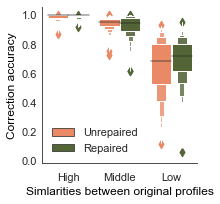

```python
unrepaired_stat['label'] = "Unrepaired"
repaired_stat['label'] = "Repaired"
combined_stat = pd.concat((unrepaired_stat,repaired_stat))

sns.set(style="whitegrid", color_codes=True, rc={"grid.linewidth": 0.01, 'grid.color': '.7',
                                                 'ytick.major.size': 2,'axes.edgecolor': '.3',
                                                 'axes.linewidth': 1,'figure.figsize':(9,4)})
#ax.set(yscale="log")
sns.catplot(x = 'mutationload_label', y = 'Correction_accuracy', kind = 'boxen', hue = "label",legend= None,
            data = combined_stat,height = 3, aspect = 1,
            order = ['High', 'Middle', 'Low'],palette=['coral','darkolivegreen'])
plt.ylabel ("Correction accuracy",  size = 12, color = "black")
plt.xlabel("Simlarities between original profiles",size = 12, color = "black")
plt.legend(loc = "lower left",frameon = False)
plt.show()
```

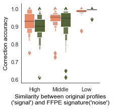

```python
sns.set(style="whitegrid", color_codes=True, rc={"grid.linewidth": 0.01, 'grid.color': '.7',
                                                 'ytick.major.size': 2,'axes.edgecolor': '.3',
                                                 'axes.linewidth': 1,'figure.figsize':(9,4)})
df_tmp = combined_stat.loc[list(combined_stat.mutationload_label.values !="Low"),:]
sns.catplot(x = 'similarity_label', y = 'Correction_accuracy', kind = 'boxen', hue = "label",legend= None,
            data = df_tmp, height = 3, aspect = 1,
            order = ['High', 'Middle', 'Low'],palette=['coral','darkolivegreen'])
plt.ylabel ("Correction accuracy",  size = 12, color = "black")
plt.xlabel("Similarity between original profiles\n('signal') and FFPE signature('noise')",
           size = 12, color = "black")
plt.show()
```

## Correction accuracy grouped by main cancer types

```python
## main cancer types include more than 20 samples within the cancer type:
cancer_types_count = unrepaired_stat.groupby('Cancer_type')['Samples'].count()
main_cancer_types = cancer_types_count.index[cancer_types_count > 20]

unrepaired_stat_filtered = unrepaired_stat.loc[[ctype in main_cancer_types for
                                                ctype in unrepaired_stat.Cancer_type],:].copy()

repaired_stat_filtered = repaired_stat.loc[[ctype in main_cancer_types for
                                                ctype in repaired_stat.Cancer_type],:].copy()

## combine unrepaired and repaired FFPE data together
repaired_stat_filtered['label'] = "Repaired"
unrepaired_stat_filtered['label'] = "Unrepaired"
combined_stat_mainCancerTypes = pd.concat((unrepaired_stat_filtered, repaired_stat_filtered))
combined_stat_mainCancerTypes.head(2)
```

|  | Samples | Cancer_type | Correction_accuracy | Similarity_FFPEsig_original | mutationload_label | similarity_label | label |
| --- | --- | --- | --- | --- | --- | --- | --- |
| 0 | Biliary-AdenoCA::SP117655 | Biliary-AdenoCA | 0.966495 | 0.646440 | Middle | Middle | Unrepaired |
| 1 | Biliary-AdenoCA::SP117556 | Biliary-AdenoCA | 0.956505 | 0.488403 | Middle | Middle | Unrepaired |

```python
## Compute the percentage of well reconstructed samples in each type
def collect_well_reconstructed_ratio (df):
    ratios = []
    types = []
    cutoff = 0.9
    for ctype in df["Cancer_type"].unique():
        passed = sum(df.loc[df.Cancer_type == ctype, "Correction_accuracy"] >= cutoff)
        total = sum(df.Cancer_type == ctype)
        ratio = passed/total
        ratios.append(ratio)
        types.append(ctype)
    ratio_df = pd.DataFrame({'Cancer_type':types, 'ratios': ratios})
    ratio_df = ratio_df.sort_values(by=['ratios'], ascending = False)
    return (ratio_df)

unrepaired_ratio_df = collect_well_reconstructed_ratio(df = unrepaired_stat_filtered.copy())
repaired_ratio_df = collect_well_reconstructed_ratio(df = repaired_stat_filtered.copy())

well_constructed_df = unrepaired_ratio_df.merge(repaired_ratio_df,on = 'Cancer_type', suffixes = ("_unrepaired",
                                                                                                  "_repaired"))
well_constructed_df_sorted = well_constructed_df.sort_values('ratios_unrepaired', ascending = False)

p_values = []
for ct in well_constructed_df_sorted.Cancer_type:
    x1 = unrepaired_stat_filtered.loc[unrepaired_stat_filtered.Cancer_type == ct,
                                 :]['Correction_accuracy'].values
    x2 = repaired_stat_filtered.loc[repaired_stat_filtered.Cancer_type == ct,
                                 :]['Correction_accuracy'].values
    t, p = mannwhitneyu(x1, x2, alternative='two-sided')
    p_values.append(p)

well_constructed_df_sorted['p_value'] = p_values

p_labels = []
for p in well_constructed_df_sorted['p_value']:
    if p < 0.001:
        p_labels.append("***")
    elif p < 0.01 and p > 0.001:
        p_labels.append("**")
    elif p < 0.05 and p > 0.01:
        p_labels.append("*")
    else:
        p_labels.append("")

well_constructed_df_sorted['labels'] = p_labels

unrepaired_ratio_num = (well_constructed_df_sorted.ratios_unrepaired * 100 ).astype("int").values
repaired_ratio_num = (well_constructed_df_sorted.ratios_repaired * 100 ).astype("int").values

well_constructed_df_sorted.head(2)
```

|  | Cancer_type | ratios_unrepaired | ratios_repaired | p_value | labels |
| --- | --- | --- | --- | --- | --- |
| 0 | Uterus-AdenoCA | 1.0 | 0.784314 | 8.202483e-03 | ** |
| 1 | CNS-GBM | 1.0 | 0.926829 | 4.601147e-10 | *** |

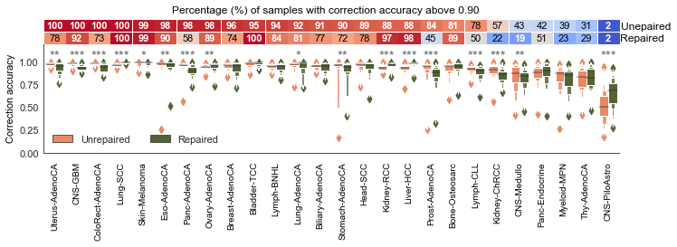

```python
sns.set(style="whitegrid", color_codes=True, rc={"grid.linewidth": 0.01, 'grid.color': '.7',
                                                 'ytick.major.size': 2, 'axes.edgecolor': '.3',
                                                 'axes.linewidth': 1})

sns.catplot(x = 'Cancer_type', y = 'Correction_accuracy', palette=['coral','darkolivegreen'],
            data = combined_stat_mainCancerTypes, order = well_constructed_df_sorted.Cancer_type.values,
            hue = "label",legend= None, kind = 'boxen', height = 2.5, aspect = 4,)
plt.xticks(rotation = 90, size = 10, color = "black")
plt.xlabel ("")
plt.ylim(0,1.2)
plt.legend(loc = "lower left", ncol = 2, frameon = False)
plt.ylabel ("Correction accuracy",  size = 11, color = "black")
cutoff = 0.9
Targeted_cancers = unrepaired_ratio_df.Cancer_type.values
length = len(Targeted_cancers)
for i in range(length):
    ## bottom pannel color bars
    left, width = 0 + 1/length * i + 0.001, 1/length - 0.002
    bottom, height = 1.12, 0.10
    right = left + width
    top = bottom + height
    ax = plt.gca()
    col_ind = unrepaired_ratio_num[i]
    colors =sns.color_palette("coolwarm", np.max(unrepaired_ratio_num) +1)
    p = plt.Rectangle((left, bottom), width, height, fill=True, color = colors[col_ind])
    p.set_transform(ax.transAxes)
    p.set_clip_on(False)
    ax.add_patch(p)

    if col_ind > 20 and col_ind < 80:
        ax.text(0.5 * (left + right), 0.5 * (bottom + top), unrepaired_ratio_num[i],
            color = "black", size = 11,
                horizontalalignment='center',verticalalignment='center', transform=ax.transAxes)
    else:
        ax.text(0.5 * (left + right), 0.5 * (bottom + top), unrepaired_ratio_num[i],
            color = "w",weight = "bold", size = 11,
                horizontalalignment='center',verticalalignment='center', transform=ax.transAxes)

    ax.text(0.5 * (left + right), 0.38 * (bottom + top), well_constructed_df_sorted['labels'][i],
            color = "dimgrey", size = 15,
                horizontalalignment='center',verticalalignment='center', transform=ax.transAxes)
    ## top pannel color bars
    left, width = 0 + 1/length * i + 0.001, 1/length - 0.002

    bottom, height = 1.003, 0.10
    right = left + width
    top = bottom + height
    ax = plt.gca()
    col_ind = repaired_ratio_num[i]
    colors =sns.color_palette("coolwarm", np.max(repaired_ratio_num) +1)
    p = plt.Rectangle((left, bottom), width, height, fill=True, color = colors[col_ind])
    p.set_transform(ax.transAxes)
    p.set_clip_on(False)
    ax.add_patch(p)

    if col_ind > 20 and col_ind < 80:
        ax.text(0.5 * (left + right), 0.5 * (bottom + top), repaired_ratio_num[i],
            color = "black", size = 11,
                horizontalalignment='center',verticalalignment='center', transform=ax.transAxes)
    else:
        ax.text(0.5 * (left + right), 0.5 * (bottom + top), repaired_ratio_num[i],
            color = "w",weight = "bold", size = 11,
                horizontalalignment='center',verticalalignment='center', transform=ax.transAxes)
## top pannel annotation
ax.text(0.53*(left + right), 0.5 *(bottom + top), "Repaired",
            color = "black", size = 12,
                horizontalalignment='center',verticalalignment='center', transform=ax.transAxes)
## bottom pannel annotation
ax.text(0.533*(left + right), 0.55 *(bottom + top), "Unepaired",
            color = "black", size = 12,
                horizontalalignment='center',verticalalignment='center', transform=ax.transAxes)
ax.text(0.25*(left + right), 0.62 *(bottom + top),
        f"Percentage (%) of samples with correction accuracy above {cutoff:.2f}",
        color = "black", size = 12,
        horizontalalignment='center',verticalalignment='center', transform=ax.transAxes)
plt.show()
```

## The corrected mutation counts vs. original mutation counts

```python
to_melted_cols = unrepaired_profiles_corrected.columns[1:]
unrepaired_correction_melted = unrepaired_profiles_corrected.melt(id_vars = ['MutationType'],
                                                                  value_vars = to_melted_cols)
unrepaired_correction_melted = unrepaired_correction_melted.rename(columns = {'variable':'Sample_IDs',
                                                                              'value':'CorrectedCount_unrepaired'})

repaired_correction_melted = repaired_profiles_corrected.melt(id_vars = ['MutationType'],
                                                                  value_vars = to_melted_cols)
repaired_correction_melted = repaired_correction_melted.rename(columns = {'variable':'Sample_IDs',
                                                                              'value':'CorrectedCount_repaired'})


profile_values['MutationType'] = (profiles['Mutation type'] + "@" + profiles['Trinucleotide']).values
original_melted = profile_values.melt(id_vars=['MutationType'],
                                         value_vars=to_melted_cols)
original_melted = original_melted.rename(columns = {'variable':'Sample_IDs',
                                                    'value':'OriginalCount'})
counts_comparison1 = original_melted.merge(unrepaired_correction_melted,
                                                 on = ['MutationType', 'Sample_IDs'])
counts_comparison =  counts_comparison1.merge(repaired_correction_melted,
                                                 on = ['MutationType', 'Sample_IDs'])
counts_comparison['Basic_types'] = profiles['Mutation type']
counts_comparison['log10_ratio_unrepaired'] = np.log10((counts_comparison.CorrectedCount_unrepaired + 1)/
                                                   (counts_comparison.OriginalCount + 1))
counts_comparison['log10_ratio_repaired'] = np.log10((counts_comparison.CorrectedCount_repaired + 1)/
                                                   (counts_comparison.OriginalCount + 1))
counts_comparison.head(2)
```

|  | MutationType | Sample_IDs | OriginalCount | CorrectedCount_unrepaired | CorrectedCount_repaired | Basic_types | log10_ratio_unrepaired | log10_ratio_repaired |
| --- | --- | --- | --- | --- | --- | --- | --- | --- |
| 0 | C>A@ACA | Biliary-AdenoCA::SP117655 | 269 | 263 | 231 | C>A | -0.009760 | -0.065876 |
| 1 | C>A@ACC | Biliary-AdenoCA::SP117655 | 148 | 139 | 114 | C>A | -0.027058 | -0.112488 |

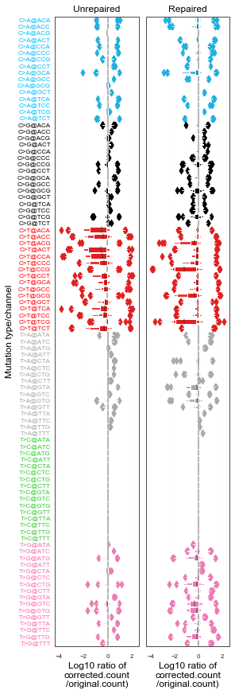

```python
col_set = ['deepskyblue','black','red','darkgrey','limegreen','hotpink']
six_basic_types = ['C>A','C>G','C>T','T>A','T>C','T>G']
type_color = {}
for t, c in zip(six_basic_types,col_set):
    type_color[t] = c
mt_color = {}
for mt in profile_values['MutationType']:
    mt_color[mt] = type_color.get(mt.split("@")[0])

f, (ax1,ax2) = plt.subplots(1,2, figsize=(4, 12), sharey = True, constrained_layout = True)
sns.boxenplot(y = 'MutationType', x = 'log10_ratio_unrepaired', data = counts_comparison, palette= mt_color,
              ax = ax1)
ax1.set_xlabel('Log10 ratio of\ncorrected.count\n/original.count)', size = 12, color = "black")

cols = [type_color.get(mt.split("@")[0]) for mt in profile_values['MutationType']]
for ticklabel, tickcolor in zip(ax1.get_yticklabels(), cols):
    ticklabel.set_color(tickcolor)

ax1.tick_params(axis='both', which='major', labelsize=8)
ax1.set_title("Unrepaired", size = 12, color = "black")
ax1.set_ylabel("Mutation type/channel", size = 12, color = "black")
sns.boxenplot(y = 'MutationType', x = 'log10_ratio_repaired', data = counts_comparison, palette= mt_color,
              ax = ax2)
ax2.set_title("Repaired", size = 12, color = "black")
ax2.set_ylabel('')
ax2.tick_params(axis='both', which='major', labelsize=8)
plt.xlabel('Log10 ratio of\ncorrected.count\n/original.count)', size = 12, color = "black")
plt.show()
```

## Correction accuracy with increasing FFPE noise load

## Simulating data

```python
well_constructed_cancers = well_constructed_df.Cancer_type[[r1 > 0.90 and r2 > 0.90
                                 for r1,r2 in zip (well_constructed_df.ratios_unrepaired,
                                                   well_constructed_df.ratios_repaired)]].values

well_constructed_cancer_profiles = profile_values.loc[:,[t.split("::")[0] in well_constructed_cancers
                                                         for t in profile_values.columns]]
well_constructed_cancers, well_constructed_cancer_profiles.shape
```

```
(array(['CNS-GBM', 'Lung-SCC', 'Skin-Melanoma', 'Eso-AdenoCA',
        'Bladder-TCC'], dtype=object),
 (96, 317))
```

```python
for level, load in zip([1,3,4,5],[10**3, 5*10**4, 10**5, 10**6]):
    simulated_df_unrepaired, simulated_df_repaired = pd.DataFrame(), pd.DataFrame()
    for i, col in enumerate(well_constructed_cancer_profiles.columns):
        npr.seed(i + 1)
        sample = well_constructed_cancer_profiles[col].to_numpy()
        simulated_df_unrepaired [col] = simulation(sample_indvidual = sample,
                                                    ffpe_sig = ffpe_sig_unrepaired,
                                                    ffpe_load = load)

        simulated_df_repaired [col] = simulation(sample_indvidual = sample,
                                                    ffpe_sig = ffpe_sig_repaired,
                                                    ffpe_load = load)
    ## write the simulated samples to Data folder
    simulated_df_unrepaired.to_csv ("./Data/Different_FFPEloads/simulated_PCAWG_FFPE_unrepaired_L" +
                                    str(level) + ".csv", index = False)
    simulated_df_repaired.to_csv ("./Data/Different_FFPEloads/simulated_PCAWG_FFPE_repaired_L" +
                                    str(level) + ".csv", index = False)
```

## Read the corrected results

The correction on noise-changed samples is performed on local HPC cluster as well.

```python
cancer_list, sample_list, accuracy_list, level_list, ffpe_load_list, label_list = [], [], [], [], [], []

path = "./Data/Different_FFPEloads/"

for label in ['unrepaired', 'repaired']:
    for level, ffpe_load in zip(['L1','L2','L3','L4','L5'],[10**3, 10**4, 5*10**4, 10**5, 10**6]):
        corrected_profiles_DiffLevel = pd.read_csv(path + label + "_profiles_corrected_" + level +".csv",
                                          sep = "\t")

        cancer = [col.split("::")[0] for col in corrected_profiles_DiffLevel.columns[1:]]
        cancer_list += cancer

        sample = [col.split("::")[1] for col in corrected_profiles_DiffLevel.columns[1:]]
        sample_list += sample

        accuracy_correction = [cosine_similarity(profile_values[col][reverse_T2C_ind].to_numpy().reshape(1,80),
                                corrected_profiles_DiffLevel[col][reverse_T2C_ind].to_numpy().reshape(1,80))[0][0]
                               for col in corrected_profiles_DiffLevel.columns[1:]]
        accuracy_list += accuracy_correction

        level_list += [level] * len(accuracy_correction)
        ffpe_load_list += [ffpe_load] * len(accuracy_correction)
        label_list += [label] * len(accuracy_correction)

## making dataframe using the collected data
correction_stats_DiffLevel = pd.DataFrame({'Cancer_type' : cancer_list,
                                         'Sample' : sample_list,
                                         'Accuracy' : accuracy_list,
                                         'Noise_level' : level_list,
                                         'FFPE_load' : ffpe_load_list,
                                         'Label' : label_list})
correction_stats_DiffLevel.head(2)
```

|  | Cancer_type | Sample | Accuracy | Noise_level | FFPE_load | Label |
| --- | --- | --- | --- | --- | --- | --- |
| 0 | Bladder-TCC | SP1086 | 0.971702 | L1 | 1000 | unrepaired |
| 1 | Bladder-TCC | SP1003 | 0.995998 | L1 | 1000 | unrepaired |

## Getting the mean correction accuracy over different noise levels

```python
mean_accuracy = correction_stats_DiffLevel.groupby(['Label', 'Noise_level']).mean()
mean_accuracy
```

| Label | Noise_level | Accuracy | FFPE_load |
| --- | --- | --- | --- |
| repaired | L1 | 0.978583 | 1000 |
|  | L2 | 0.974264 | 10000 |
|  | L3 | 0.961877 | 50000 |
|  | L4 | 0.951857 | 100000 |
|  | L5 | 0.862607 | 1000000 |
| unrepaired | L1 | 0.978965 | 1000 |
|  | L2 | 0.978391 | 10000 |
|  | L3 | 0.974469 | 50000 |
|  | L4 | 0.965996 | 100000 |
|  | L5 | 0.920085 | 1000000 |

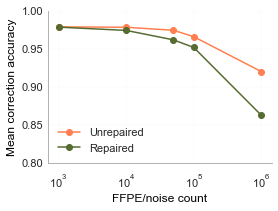

```python
sns.set(style="whitegrid", color_codes=True, rc={"grid.linewidth": 0.1, 'grid.color': '.9',
                                                 'ytick.major.size': 2,'axes.edgecolor': '.7',
                                                 'axes.linewidth': 1,'figure.figsize':(4,2.8)})

f, ax = plt.subplots()
ax.set(xscale="log")
plt.plot( "FFPE_load", "Accuracy", data = mean_accuracy.loc['unrepaired'],
         linestyle='-',color = 'coral', marker='o', label = "Unrepaired")

plt.plot( "FFPE_load", "Accuracy", data = mean_accuracy.loc['repaired'],
         color = "darkolivegreen", linestyle='-', marker='o', label = "Repaired")
plt.ylim(0.8,1)
plt.legend(frameon = False)
plt.xlabel ("FFPE/noise count", size = 12, color = "black")
plt.ylabel("Mean correction accuracy",size = 12, color = "black")
sns.despine()
plt.show()
```